# Analysis of Fiscal Convergence in Colorado

Testing whether or not the constraints imposed by Tax and Expenditure Limitations (TELs) lead to local fiscal convergence is difficult to achieve with the prevailing models in this area. Most of the empirical work attempts to study TELs across states, and as such, focuses on statewide definitions of TELs. Obviously this covers up local variation, but perhaps more interestingly, this choice in geographic scope encourages certain questions. What is the impact of TELs on revenue volatility ([St. Clair 2012](http://papers.ssrn.com/sol3/papers.cfm?abstract_id=2151690))? Do TELs constrain property taxes ([Dye & McGuire 1997](http://www.sciencedirect.com/science/article/pii/S0047272797000479))? Do TELs constrain growth in employment and wages ([Poterba & Rueben 1995](http://www.jstor.org/discover/10.2307/2117953?uid=3739256&uid=2&uid=4&sid=21102688756161))? Exploration of such questions can rely on binary indicators of TEL presence, or indices that incorporate information about legal basis, ease of circumvention, and scope of application among other characteristics.

Comparatively little research examines the within state dynamic. Once one asks the question about local differences, modeling the parameter of interest is a different game altogether. In this case, the researcher must tease out variation among fiscal circumstances among jurisdictions for whom the statewide legislation is a common denominator. Once this issue comes to fore, one is immediately confronted with the following question: if the statewide legislation does not vary cross-sectionally, do we expect uniform impact across all local jurisdictions at time $t$? The unlikely nature of this situation is the motivating factor for this study. Fiscal behavior is a function of economic circumstance, and given the variation in economic bases across a given state, one would expect that TELs have different impacts in different jurisdiction. In identifying patterns in the variation of local revenues and expenditures, [Mullins (2004)](http://onlinelibrary.wiley.com/doi/10.1111/j.0275-1100.2004.00350.x/abstract?deniedAccessCustomisedMessage=&userIsAuthenticated=false) stands out as an important example of why higher resolution is needed.

A second, and related, question is whether or not we expect a temporal element in the impact of TELs. Is it more constraining as a jurisdiction spends more time operating within the TEL environment? Furthermore, given the fact that the TEL environment in Colorado is composed of overlapping policies, do we expect interaction effects to play a significant role? To shed light on such questions, this study employs spatial techniques to examine panel data of county-level fiscal and economic data in Colorado over the 1987-2009 time period.

## Strategy

This analysis seeks to identify spatial clustering of fiscal behavior. To do so we will examine the fiscal clustering over the given time period, and seek to identify whether or not it has changed as a consequence of the four primary elements of Colorado TEL structure:

1. General Statewide Limit on Property Tax Revenue (SLPTR): Local property tax revenues may not increase by more than 5.5% in a given year (the limit was 7% before 1988)
2. Gallagher Amendment (GA): Assessment rates for residential property are set statewide, calculated to keep historical ratios of residential and non-residential property tax revenue consistent (with some minor space for modification)
3. Taxpayer Bill of Rights (TABOR): Limits annual growth in revenues to inflation plus a measure of growth (new construction for local governments and enrollment for school districts)
4. Amendment 23 (A23): Mandates minimum increases in school funding and removes a portion of revenue from the TABOR base

There are three main stages to this inquiry: verification of variation, non-spatial modeling, spatial modeling.

#### Verification of Variation

The hypothesis rests on the idea that not only does spatial clustering of fiscal behavior occur, the nature of the clustering must vary over time. To capture this we will take snapshots of fiscal and economic hot spots every five years, starting with 1987. These hotspots will be identified using Local Indicators of Spatial Autocorrelation (LISAs) developed initially in Getis & Ord (1992) and Anselin (1995). These are the $G_i^*$ and Moran's $I_i$ statistics, respectively.

#### Non-Spatial Modeling

The non-spatial modeling will employ pooled Ordinary Least Squares (OLS), pursued with the knowledge that ignorance of dependency structures across time and space will disrupt the capacity to identify a clear statistical signal. More than anything, this component of the analysis serves to establish a baseline, against which spatial analyses may be compared.

#### Spatial Modeling

Once variation across time and space has been established, a series of spatial models of increasing complexity will be used to measure the impact of TEL intensity on the revenue capacity of a given jurisdiction. The goal is to demonstrate, over the course of examining all the evidence, that TELs create wedges between jurisdictions that feature differing economic starting positions.

## Conceptual Infrastructure

The two conceptual drivers of this analysis will be measures of TEL intensity, and fiscal convergence. These two concepts are discussed separately for 1) their primary importance, and 2) to provide modularity to the analysis. With respect to the latter, the choice of indicators used for intensity and convergence is not final. Any choice is likely to exhibit some unfavorable characteristics. As this research program continues, it is useful to allow for new indicators that may complement or improve upon those that have come before.

#### TEL Intensity

An ideal intensity score would capture three characteristics of any given county at time $t$:

1. The accumulation of statewide legislation over time;
2. The proliferation of locally derived exemptions from TABOR and SLPTR; and,
3. The local economic dynamics that may trigger a breach in the ceilings imposed by the aforementioned legislation.

The initial indicator to be used is an ordinal score that regrettably captures only the first two. Effectively, the score adds a point for each additional constraint. For example, all counties in 1987 will carry a score of two given the general application of both SLPTR and GA. These scores are subsequently modified by De-Brucing, which 47 of 64 counties chose to do in the 1993-2009 time period. The exemptions from these De-Brucing efforts are for TABOR and sometimes the SLPTR. If only TABOR is waived, one point will be removed. Two will be removed if both are waived.

#### Fiscal Convergence

In a broad sense, we can think of fiscal capacity as a measure of the resources available to a given jurisdiction. If two jurisdictions capture the same amount of revenue per constituent, it stands to reason that they will make expenditure decisions that yield similar levels of utility. From this perspective, revenues per capita emerges as a reasonable indicator to serve as the basis for a determination of fiscal convergence. Indeed, *this will be the starting point in this research program.*

That being said, fiscal decisions are not made in a vacuum - initial conditions matter. It is therefore desirable to capture a more robust characterization of the fiscal behavior of a given county. A property base composed of primarily residential housing can and should be economically characterized in a different fashion than a base characterized by heavy industry. The problem that the researcher must confront is how to deal with the increased dimensionality of multivariate descriptions of a base. Comparisons of economic bases broken down by NAICS codes are far less straightforward than the differences in point values.

One way fairly robust way to reduce the number of variables one deals with is to utilize [principal component analysis](http://www.youtube.com/watch?v=UUxIXU_Ob6E&list=WLCAC16A321C6C5555), which in effect attempts to capture information about the latent process driving the variation in the directly observed variables.

Another approach is to use a similarity score, in particular a metric that captures information about the size of given industries and their relative importance within a given jurisdiction. The author proposes a measure comprised of two distance metrics: Kendall's $\tau$ and Euclidean Distance. The former captures the distance between two 1-d ranking arrays, and the latter captures the distance between two 1-d value arrays. The interpretation of Kendall's $\tau$ is as follows:

+**1** indicates the same rank order; +**-1** indicates the reverse order; and, +**0** indicates no relation.

Relationships are thus indicated by larger absolute magnitude, in constrast to Euclidean Distance, which decreases with similarity. Consequently, the following statistic grows as the similarity between two compositional arrays grows:

$\frac{\tau}{ED}$

## Calculation of Intensity Score

To implement the intensity score, we are going to append it to the existing fiscal dataset built in the notebook called *CO_county_fin*.

```python
import numpy as np
import pandas as pd
from pandas import Series,DataFrame

#Enable HTML coercion
from IPython.display import HTML

#Set print width
pd.set_option('line_width',140)

#Set plot style
pd.options.display.mpl_style='default'

#Establish working directory
workdir='/home/choct155/Google Drive/Dissertation/Data/'

#Read in data
co=pd.read_csv(workdir+'CO_county_ggfin.csv')

co
```

```
<class 'pandas.core.frame.DataFrame'>
Int64Index: 2240 entries, 0 to 2239
Data columns (total 81 columns):
Unnamed: 0                      2240  non-null values
NAME_x                          2240  non-null values
AUDIT_YEAR                      2240  non-null values
LGTYPE_ID                       2240  non-null values
LG_ID                           2240  non-null values
REV_TOTAL                       2240  non-null values
REV_TOTAL_TAX                   2240  non-null values
REV_PROPERTY_TAX                2240  non-null values
REV_SO_TAX                      2240  non-null values
REV_SALES_USE_TAX               2240  non-null values
REV_OCCUPATION_TAX              2240  non-null values
REV_FRANCHISE_TAX               2240  non-null values
REV_OTHER_TAX                   2240  non-null values
REV_LODGING_TAX                 2240  non-null values
REV_REAL_ESTATE_TRANSFER_TAX    2240  non-null values
REV_UNCLASS_TAX                 2240  non-null values
REV_LICENSES                    2240  non-null values
REV_CHARGES                     2240  non-null values
REV_FINES                       2240  non-null values
REV_TRANSFER_IN                 2240  non-null values
REV_INTGOVT                     2240  non-null values
REV_HUT                         2240  non-null values
REV_CIGARETTE_TAX               2240  non-null values
REV_MOTOR_VEH_FEE               2240  non-null values
REV_CTF                         2240  non-null values
REV_SOCIAL_SERVICE              2240  non-null values
ALL_OTHER_INTGOVT               2240  non-null values
REV_MISC                        2240  non-null values
REV_INTEREST                    2240  non-null values
EXP_TOTAL                       2240  non-null values
EXP_TOTAL_OPERATING             2240  non-null values
EXP_GEN_GOVT                    2240  non-null values
EXP_JUDICIAL                    2240  non-null values
EXP_TOTAL_PUBLIC_SAFETY         2240  non-null values
EXP_POLICE                      2240  non-null values
EXP_FIRE                        2240  non-null values
EXP_OTHER_PUBLIC_SAFETY         2240  non-null values
```

[output cut: 30 more lines]

```
COUNTYFP                        2240  non-null values
COUNTYNS                        2240  non-null values
CSAFP                           420  non-null values
FUNCSTAT                        2240  non-null values
GEOID                           2240  non-null values
INTPTLAT                        2240  non-null values
INTPTLON                        2240  non-null values
LSAD                            2240  non-null values
METDIVFP                        0  non-null values
MTFCC                           2240  non-null values
NAME_y                          2240  non-null values
NAMELSAD                        2240  non-null values
STATEFP                         2240  non-null values
sorting_id                      2240  non-null values
dtypes: float64(63), int64(11), object(7)
```

```python
print co['POPULATION'].head()
```

```
0    864698.141264
1    839675.140598
2    800428.341584
3    788366.457055
4    727004.318182
Name: POPULATION, dtype: float64
```

**IMPORTANT:** Once I have an internet connection, I need to fix the population figures (which were deflated along with the fiscal data in CO_county_fin

As can be seen, the DataFrame contains fiscal and spatial information, but the spatial content is only descriptive (not tied to a projection and datum). We will return to this later, after construction of both a measure of TEL intensity and a measure of fiscal convergence.

Recall that the intensity score is just a simple index that grows incrementally with each new piece of legislation. We are only looking at the 1987-2009 period (a range driven by the industrial activity and fiscal data currently in possession). The importance dates are as follows:

- 1987: Start date in which all counties are scored 2 (SLPTR + GA)
- 1992: TABOR initiated, all counties increase to 3
- 2000: A23 initiated, all counties increase by 1

Recall that after TABOR, De-Brucing becomes a factor, which can remove one (waiver of TABOR) or two points (waiver of TABOR + SLPTR).

```python
#Subset data to after 1987
co_87=co[co['AUDIT_YEAR']>1986].reset_index()

##Creation of initial intensity score (pre-De-Brucing)
#Initialize variable
co_87['int_temp']=np.NaN

#Conditionally set scores based on time periods above
co_87.ix[co_87['AUDIT_YEAR']<1992,'int_temp']=2
co_87.ix[(co_87['AUDIT_YEAR']>1991) & (co_87['AUDIT_YEAR']<2000),'int_temp']=3
co_87.ix[co_87['AUDIT_YEAR']>1999,'int_temp']=4
```

Now we need to integrate the impact of De-Brucing. The dictionary below was taken from a previous Notebook called *tabor_score*.

```python
debruce_dict={'Adams':[2002,1], 'Alamosa':[1997,1], 'Archuleta':[1994,0], 'Baca':[1995,0],
              'Bent':[1993,0], 'Boulder':[2005,0], 'Chaffee':[1993,0], 'Cheyenne':[1996,0],
              'Clear Creek':[1999,1], 'Conejos':[1996,0], 'Costilla':[1997,0], 'Crowley':[1994,0],
              'Custer':[1997,1], 'Dolores':[2000,1], 'Douglas':[1997,1], 'Eagle':[1995,0],
              'Garfield':[1994,0], 'Grand':[1996,1], 'Gunnison':[2000,0], 'Hinsdale':[2006,1],
              'Huerfano':[2007,1], 'Jackson':[1999,1], 'Kiowa':[1997,0], 'Kit Carson':[1997,0],
              'La Plata':[2002,1], 'Lake':[2011,1], 'Larimer':[1999,1], 'Lincoln':[1995,0],
              'Logan':[1997,0], 'Mineral':[1995,0], 'Moffat':[1996,0], 'Montezuma':[2002,1],
              'Morgan':[1996,0], 'Otero':[1995,0], 'Ouray':[2002,1], 'Phillips':[1995,0],
              'Pitkin':[1994,0], 'Prowers':[1994,0], 'Rio Blanco':[1996,1], 'Rio Grande':[1999,1],
              'Saguache':[1996,1], 'San Juan':[1995,1], 'San Miguel':[2005,0], 'Sedgwick':[1996,1],
              'Summit':[1998,0], 'Teller':[1997,1], 'Washington':[1996,1], 'Yuma':[2004,1]}
```

It contains the 48 counties that De-Bruced during the 1993-2011 time period as keys. The value array contains two values. In the first position is the year in which the TABOR waiver was passed in the county. The second position indicates whether or not this legislation also included a waiver from the 5.5% limit imposed by SLPTR. These data were acquired from the resources of [Colorado Counties, Inc.](http://ccionline.org/). In particular, these are taken from [tabulations of TABOR related activity](http://ccionline.org/download/Debruced%20Counties.pdf).

It should be noted that in some cases (such as Archuleta County), these waivers were effectively constructed over time in overlapping legislation. The strategy has been to take the latest year, which in most cases represents the commencement of broad exemption from TABOR.

Archuleta County is somewhat unique in that it's piecemail construction actually included a SLPTR waiver (2006) well after the exemption from TABOR (1994). Furthermore, there is a break in the TABOR waiver coverage for this county.

```python
#Create new De-Brucing variable
co_87['db_temp']=np.NaN
for key in debruce_dict.keys():
    #co_87.ix[(co_87['FNAME']==key) & (co_87['AUDIT_YEAR']<debruce_dict[key][0]),'db_temp']=0
    if debruce_dict[key][1]==1:
        co_87.ix[(co_87['FNAME']==key) & (co_87['AUDIT_YEAR']>debruce_dict[key][0]-1),'db_temp']=2
    else:
        co_87.ix[(co_87['FNAME']==key) & (co_87['AUDIT_YEAR']>debruce_dict[key][0]-1),'db_temp']=1

#Replace all in NaN in db with zero
co_87['db']=co_87['db_temp'].replace(np.NaN,0)

#Calculate intensity composite
co_87['intensity']=co_87['int_temp']-co_87['db']

#print co_87[['FNAME','AUDIT_YEAR','int_temp','db_temp','db','intensity']].head(100).to_string()
print co_87['intensity'].describe()
```

```
count    1472.000000
mean        2.663043
std         0.747017
min         1.000000
25%         2.000000
50%         3.000000
75%         3.000000
max         4.000000
dtype: float64
```

## Calculation of Fiscal Convergence Measurement

The measure used, revenue per capita, is very straightforward to calculate given the presence of both *REV_TOTAL* and *POPULATION* in the DataFrame.

```python
co_87['pcrev']=co_87['REV_TOTAL']/co_87['CTY_POP']
print co_87['pcrev'].describe()
```

```
count    1472.000000
mean     1403.622430
std       830.465026
min       388.991392
25%       805.763760
50%      1165.802921
75%      1760.594097
max      5345.363711
dtype: float64
```

It may also become useful at some point to look at other per capita measures (total expenditures, total debt, and intergovernmental revenues). Consequently, these values are also calculated.

```python
co_87['pcexp']=co_87['EXP_TOTAL']/co_87['CTY_POP']
co_87['pcintgov']=co_87['REV_INTGOVT']/co_87['CTY_POP']
co_87['TOTAL_DEBT']=co_87['GO_DEBT_GEN']+co_87['REVENUE_DEBT_GEN']+co_87['OTHER_DEBT_GEN']
co_87['pcdebt']=co_87['TOTAL_DEBT']/co_87['CTY_POP']
```

## Preparation for Spatial Exploration

To evaluate whether or not we see spatial clustering (and whether it varies over time), we need to associated the data spatially. While we have county names and attributes, spatial content means that the data must be associated with a projection and datum. Following this, neighborhoods must be defined. In this context, a neighborhood are the counties that the researcher believes exert spatial influence on the county of choice.

To begin this process, we need to read in the shapefile of interest, the boundary layer for counties in the US.

```python
import pysal

#Establish working directory
workdir='/home/choct155/Google Drive/Dissertation/Data/spatial/US/'

#Open shapefile
us_cty=pysal.open(workdir+'tl_2012_us_county.shp')
```

We are only concerned with the subset of the information dealing with Colorado. Thus, we need to figure out the key for the subset (from the .dbf associated with the shapefile), and then subset the shapefile.

```python
#Open data table
us_cty_db=pysal.open(workdir+'tl_2012_us_county.dbf')

#Convert to DataFrame for easy exploration
us_cty_df=DataFrame(dict([(col, np.array(us_cty_db.by_col(col))) for col in us_cty_db.header]))

#Explore state variable ('08' is the FIPS code for Colorado)
print us_cty_df[['NAME','GEOID','INTPTLAT','INTPTLON']][us_cty_df['STATEFP']=='08'].head(30)

print '\nTHE COLORADO SUBSET CONTAINS',len(set(us_cty_df['NAME'][us_cty_df['STATEFP']=='08'])),'COUNTIES'
```

```
            NAME  GEOID     INTPTLAT      INTPTLON
2169    Hinsdale  08053  +37.8116669  -107.3833350
2170       Delta  08029  +38.8617559  -107.8647570
2171      Gilpin  08047  +39.8610823  -105.5289473
2174    Costilla  08023  +37.2775474  -105.4289399
2176     Jackson  08057  +40.6634319  -106.3292476
2177     Chaffee  08015  +38.7382441  -106.3169553
2179      Elbert  08039  +39.3105817  -104.1177288
2205      Teller  08119  +38.8719937  -105.1825519
2206     Prowers  08099  +37.9581814  -102.3921613
2209    Sedgwick  08115  +40.8715679  -102.3553579
2210      Denver  08031  +39.7618502  -104.8806409
2211  Rio Grande  08105  +37.4857631  -106.4532135
2213   Montezuma  08083  +37.3380247  -108.5957864
2214      Moffat  08081  +40.5739839  -108.2045214
```

[output cut: 18 more lines]

#### Creation of Colorado-Based Subset

With the key identified, the subset can be acquired.

Note that my careless placement of the GeoDa sandbox necessitates a modification of the IPython system path before using the tools it offers.

```python
import sys
sys.path.append('/home/choct155/analysis/geoda_sandbox/sandbox/')
```

```python
from pyGDsandbox.geo_tools import clip_shp

#Identify input and output shapefiles
us_shp=workdir+'tl_2012_us_county.shp'
co_shp=workdir+'co_county.shp'

#Identify column name
state='STATEFP'

#Identify key signifying records to be kept
keys=['08']

#Subset to Colorado
clipped=clip_shp(us_shp,state,keys,shp_out=co_shp)
```

```
('WARNING: GDAL (and ogr) are not installed. This may create', 'some methods to not work')
```

The new shapefile should corroborate the county count from the old subset.

```python
#Open new shapefile
CO_shp=pysal.open(workdir+'co_county.shp')

print 'THE NEW COLORADO-SPECIFIC SHAPEFILE CONTAINS',len(CO_shp),'COUNTIES'
```

```
THE NEW COLORADO-SPECIFIC SHAPEFILE CONTAINS 64 COUNTIES
```

Visual verification of the shapefile complements the count check. The image below was created in RStudio using the shapefile created in this Notebook.

```python
from IPython.display import SVG
SVG(workdir+'co_county_plot.svg')
```

[figure not shown]

#### Creation of Spatial Weight Matrices

To evaluate clustering, LISAs require a definition of the linkages of importance between jurisdictions. Said differently, they require an explicitly defined neighborhood. Spatial analysis is generally sensitive to choice in weight matrices (cite GA), so we will test multiple neighborhood criteria and look for corroboration among the tests.

We will define neighborhoods by the following metrics:

1. Rook Contiguity
2. Queen Contiguity
3. Distance Band - Binary
4. Distance Band - Continuous (Inverse Distance Decay)
5. Kernel (Gaussian Decay)

Once defined, these weight matrices will be of general use throughout the rest of the analysis. The Rook and Queen weights are straightforward to generate.

```python
#Generate rook weights
w_rook=pysal.rook_from_shapefile(workdir+'co_county.shp')

#Generate queen weights
w_queen=pysal.queen_from_shapefile(workdir+'co_county.shp')
```

The Distance Band weight generation is a multi-step process. This weight matrix will be defined so as to ensure that each county has at least one neighbor. Consequently, the minimum distance at which this occurs must be extracted from the data.

Once the threshold is identified, two weight matrices are generated. The first is binary (like Rook and Queen contiguity). All neighbors in the neighborhood have equivalent weights. The second is continuous, and will decay in inverse proportion to the distance.

```python
#Calculate minimum distance at which each county has at least one neighbor
thresh=pysal.min_threshold_dist_from_shapefile(workdir+'co_county.shp')

#Calculate binary distance band weights
w_db_b=pysal.threshold_binaryW_from_shapefile(workdir+'co_county.shp',thresh)

#Calculate continous distance band weights
w_db_c=pysal.threshold_continuousW_from_shapefile(workdir+'co_county.shp',thresh)
```

Kernel weights are much like continuous Distance Band weight matrices, except they feature more complicated decay functions. In this instance, the decay function is Gaussian.

```python
#Generate kernel based weights
w_kern=pysal.kernelW_from_shapefile(workdir+'co_county.shp',function='gaussian')
```

It is useful to get a sense of the variance in neighborhood size. The following plots provide a view of cardinality (or neighborhood size) distribution for each weighting scheme. The *histogram* method returns a list of tuples identifying a given neighborhood size (first position) and the number of jurisdictions, $i$, that have neighborhoods of said size (second position).

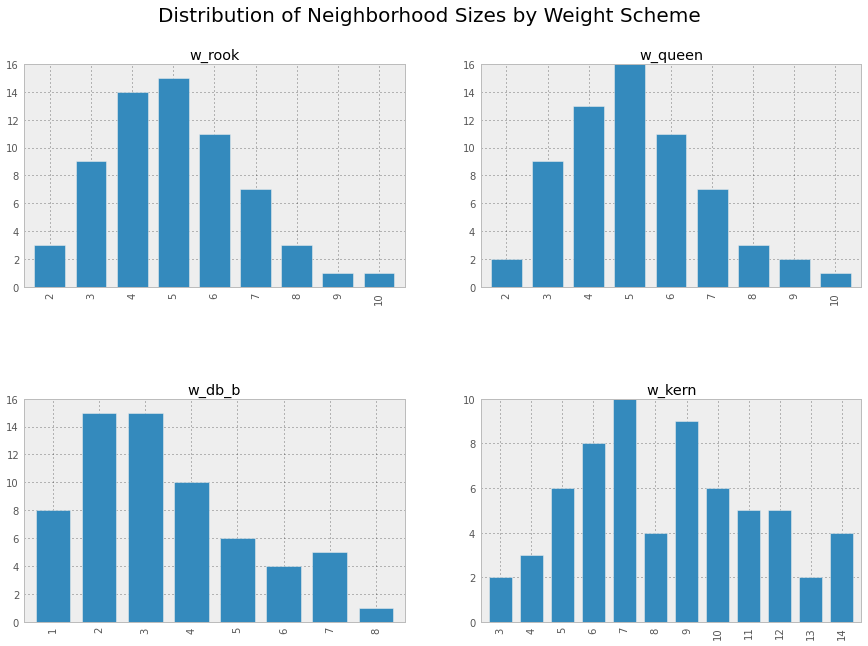

```python
#Define function for generating cardinality series
def card(w):
    data=[y for x,y in w.histogram]
    ind=[x for x,y in w.histogram]
    w_series=Series(data,index=ind)
    return w_series

#Set plot plot size
plt.rcParams['figure.figsize']=15,10

#Construct list of weight matrices
weights=[w_rook,w_queen,w_db_b,w_kern]

#Construct list of titles
titles=['w_rook','w_queen','w_db_b','w_kern']

#Plot neighborhood size by county
fig,axes=plt.subplots(2,2)
plt.suptitle('Distribution of Neighborhood Sizes by Weight Scheme',fontsize=20)
i=0
for w in weights:
    card(w).plot(kind='bar',title=titles[i],ax=axes[i//2,i%2])
    i+=1
```

## Measuring Spatial Clustering Over Time

To evaluate the spatial elements over time, LISAs must be calculated for each year in the 1987-2009 time period. To achieve this, 23 year-specific shapefiles will be constructed with the relevant fiscal/TEL variables merged by county name. For the time being, the data to be merged will contain only the following variables:

- FNAME = County Name
- AUDIT_YEAR = Fiscal Information Year
- REV_TOTAL = Total Revenue
- REV_INTGOVT = Total Intergovernmental Revenue
- EXP_TOTAL = Total Expenditures
- TOTAL_DEBT = Total Outstanding Debt
- CTY_POP = County Population
- intensity = TEL Intensity
- pcrev = Revenue Per Capita (primary measure of fiscal convergence)
- pcexp = Expenditures Per Capita
- pcintgov = Intergovernmental Revenue Per Capita
- pcdebt = Outstanding Debt Per Capita

This subset will then be split by year in preparation for the merge with the shapefile data.

```python
#Subset to columns of interest
co_merge=co_87.reindex(columns=['FNAME','AUDIT_YEAR','REV_TOTAL','REV_INTGOVT','EXP_TOTAL','TOTAL_DEBT',\
                                'CTY_POP','intensity','pcrev','pcexp','pcintgov','pcdebt'])

#Split data by year and deposit into dictionary
co_dict={}
for i in range(1987,2010):
    co_dict.update({'yr'+str(i):co_merge[co_merge['AUDIT_YEAR']==i].reset_index()})
print co_dict['yr1999'].head()
co_dict['yr2000'].head()
```

```
   index      FNAME  AUDIT_YEAR     REV_TOTAL      REV_INTGOVT     EXP_TOTAL       TOTAL_DEBT  CTY_POP  intensity        pcrev  \
0     12      Adams        1999  2.065297e+08  59460988.793517  2.050956e+08  14537626.773709   330415          3   625.061382
1     35    Alamosa        1999  1.386245e+07   7665551.479592  1.452737e+07      2195.213085    16461          1   842.139154
2     58   Arapahoe        1999  1.899706e+08  51693677.277911  1.965649e+08  25599516.662665   488367          3   388.991392
3     81  Archuleta        1999  1.155086e+07   3119514.957983  1.758509e+07    600478.973589     9581          2  1205.600778
4    104       Baca        1999  6.864487e+06   4317408.619448  6.667807e+06    219252.217887     4551          2  1508.346887

         pcexp    pcintgov     pcdebt
0   620.721359  179.958503  43.998084
1   882.532601  465.679575   0.133358
2   402.494232  105.850062  52.418605
3  1835.413315  325.593879  62.673935
4  1465.130120  948.672516  48.176712
```

|  | index | FNAME | AUDIT_YEAR | REV_TOTAL | REV_INTGOVT | EXP_TOTAL | TOTAL_DEBT | CTY_POP | intensity | pcrev | pcexp | pcintgov | pcdebt |
| --- | --- | --- | --- | --- | --- | --- | --- | --- | --- | --- | --- | --- | --- |
| 0 | 13 | Adams | 2000 | 2.602143e+08 | 1.060497e+08 | 2.351329e+08 | 13437113.336237 | 363857 | 4 | 715.155339 | 646.223439 | 291.459957 | 36.929655 |
| 1 | 36 | Alamosa | 2000 | 1.347668e+07 | 7.263447e+06 | 1.323576e+07 | 0.000000 | 14966 | 2 | 900.486435 | 884.388855 | 485.329887 | 0.000000 |
| 2 | 59 | Arapahoe | 2000 | 2.143910e+08 | 5.763030e+07 | 2.109306e+08 | 93104741.445993 | 487967 | 4 | 439.355594 | 432.264137 | 118.102857 | 190.801307 |
| 3 | 82 | Archuleta | 2000 | 1.325225e+07 | 4.228060e+06 | 1.457983e+07 | 503865.731707 | 9898 | 3 | 1338.881186 | 1473.007837 | 427.163096 | 50.905812 |
| 4 | 105 | Baca | 2000 | 6.291640e+06 | 3.990596e+06 | 6.602893e+06 | 41106.271777 | 4517 | 3 | 1392.880232 | 1461.787240 | 883.461505 | 9.100348 |

Given year-specific fiscal/TEL data, the shapefile data must be converted from .dbf to a [pandas](http://pandas.pydata.org/) DataFrame and merged.

```python
#Open data table
co_cty_db=pysal.open(workdir+'co_county.dbf')

#Convert to DataFrame for easy exploration
co_cty_df=DataFrame(dict([(col, np.array(co_cty_db.by_col(col))) for col in co_cty_db.header]))

#Create sort_id variable
co_cty_df['sort_id']=co_cty_df.index

#Merge spatial data with fiscal/TEL data by year and place in a dictionary
co_sp_dict={}
for key in co_dict.keys():
    co_sp_dict.update({key:pd.merge(co_cty_df,co_dict[key],left_on='NAME',right_on='FNAME').sort(column='sort_id')})
print co_sp_dict['yr2000']
HTML(co_sp_dict['yr2000'][['AUDIT_YEAR','INTPTLAT','INTPTLON','NAME','FNAME','intensity','pcrev','sort_id']].head().to_html())
```

```
<class 'pandas.core.frame.DataFrame'>
Int64Index: 64 entries, 0 to 63
Data columns (total 31 columns):
ALAND          64  non-null values
AWATER         64  non-null values
CBSAFP         64  non-null values
CLASSFP        64  non-null values
COUNTYFP       64  non-null values
COUNTYNS       64  non-null values
CSAFP          64  non-null values
FUNCSTAT       64  non-null values
GEOID          64  non-null values
INTPTLAT       64  non-null values
INTPTLON       64  non-null values
LSAD           64  non-null values
METDIVFP       64  non-null values
MTFCC          64  non-null values
NAME           64  non-null values
NAMELSAD       64  non-null values
STATEFP        64  non-null values
sort_id        64  non-null values
index          64  non-null values
FNAME          64  non-null values
AUDIT_YEAR     64  non-null values
REV_TOTAL      64  non-null values
REV_INTGOVT    64  non-null values
EXP_TOTAL      64  non-null values
TOTAL_DEBT     64  non-null values
CTY_POP        64  non-null values
intensity      64  non-null values
pcrev          64  non-null values
pcexp          64  non-null values
pcintgov       64  non-null values
pcdebt         64  non-null values
dtypes: float64(9), int64(6), object(16)
```

|  | AUDIT_YEAR | INTPTLAT | INTPTLON | NAME | FNAME | intensity | pcrev | sort_id |
| --- | --- | --- | --- | --- | --- | --- | --- | --- |
| 0 | 2000 | +37.8116669 | -107.3833350 | Hinsdale | Hinsdale | 4 | 3371.906320 | 0 |
| 1 | 2000 | +38.8617559 | -107.8647570 | Delta | Delta | 4 | 655.498519 | 1 |
| 2 | 2000 | +39.8610823 | -105.5289473 | Gilpin | Gilpin | 4 | 3232.355300 | 2 |
| 3 | 2000 | +37.2775474 | -105.4289399 | Costilla | Costilla | 3 | 2372.374177 | 3 |
| 4 | 2000 | +40.6634319 | -106.3292476 | Jackson | Jackson | 2 | 2242.755850 | 4 |

#### Evaluating Local Moran's I

Moran's I measures the global spatial autocorrelation in an attribute $y$ over a given neighborhood defined by $w_{ij}$.

$I=\frac{n}{S_0}\frac{(\sum_i\sum_jz_iw_{i,j}z_j)}{(\sum_iz_i^2)}=\frac{n}{(\sum_i\sum_jw_{i,j})}\frac{\sum_i\sum_j(y_i-\bar y)(y_j-\bar y)}{(y_i-\bar y)^2}$

The local version is implemented as follows:

$I_i=\frac{\sum_j z_i w_{i,j} z_j}{\sum_i z_i^2}=\frac{\sum_j (y_i-\bar y)w_{i,j}(y_j-\bar y)}{\sum_i(y_i-\bar y)^2}$

which is then calculated for each of $i$ observations.

Why do we care about local Moran's I? It allows us to get a kind of topological view of autocorrelation. Just as providing a single moment of a data set masks distributional content, providing a global parameter masks regional dynamics. In this way, we are able to identify clusters of counties with similar per capita revenue values.

Thus, the statistic is calculated for each year-specific subset of the fiscal data, and each of the considered weight schemes.

```python
wname=['w_rook_i','w_queen_i','w_db_b_i','w_db_c_i','w_kern_i']
for key in co_sp_dict.keys():
    i=0
    for w in [w_rook,w_queen,w_db_b,w_db_c,w_kern]:
        lm=pysal.Moran_Local(co_sp_dict[key]['pcrev'].values,w,permutations=9999)
        co_sp_dict[key][wname[i]]=lm.z_sim
        i+=1
```

```python
co_sp_dict['yr2000'][['AUDIT_YEAR','NAME','pcrev','w_rook_i','w_queen_i','w_db_b_i','w_db_c_i','w_kern_i']].head()
```

|  | AUDIT_YEAR | NAME | pcrev | w_rook_i | w_queen_i | w_db_b_i | w_db_c_i | w_kern_i |
| --- | --- | --- | --- | --- | --- | --- | --- | --- |
| 0 | 2000 | Hinsdale | 3371.906320 | 3.503884 | 3.580748 | 6.206690 | 7.455208 | 6.601721 |
| 1 | 2000 | Delta | 655.498519 | 1.304842 | 1.332945 | 0.955864 | 0.957419 | 0.669578 |
| 2 | 2000 | Gilpin | 3232.355300 | -1.230512 | -1.258628 | 1.322135 | 0.642737 | 1.372555 |
| 3 | 2000 | Costilla | 2372.374177 | -1.594783 | -1.630977 | -1.297324 | -1.284772 | -0.661698 |
| 4 | 2000 | Jackson | 2242.755850 | -0.046787 | -0.048656 | 0.782376 | 0.776760 | 1.221399 |

#### Getis & Ord's $G_i^*$

As noted by Anselin (1995), the interpretation of Moran's $I_i$ is insufficient for a comprehensive knowledge of the clustering behavior of spatially related activities.

$G_i^*$ is a natural complement in this regard, because it explains a fundamentally different kind of spatial association. $I_i$ returns high values when *similar* values are clustered and low values when *disimilar* values are clustered. Whether or not they are high or low does not impact the magnitude of the statistic. By contrast, $G_i^*$ returns high values when *high* values are clustered and low values when *low* values are clustered. If one were to rely solely on the former, it would not be possible to determine the distinction between fundamentally different clusters. For example, clustering of low revenue capacity would be indistinguishable from clustering of high revenue capacity. If one were to rely solely on the latter, it would not be possible to detect unusual patterns of discontinuity arose (discontinuities that were beyond that which would occur with random shuffling of values). In this instance local anomoly detection would be made more difficult, and the measure does not lend itself to the identification of spatial non-stationarity.

These measures will also be integrated into the new shapefiles soon to be created.

```python
from pysal.esda.getisord import G_Local

wname_g=['w_rook_g','w_queen_g','w_db_b_g','w_db_c_g','w_kern_g']
for key in co_sp_dict.keys():
    i=0
    for w in [w_rook,w_queen,w_db_b,w_db_c,w_kern]:
        lm=pysal.G_Local(co_sp_dict[key]['pcrev'].values,w,permutations=9999)
        co_sp_dict[key][wname_g[i]]=lm.z_sim
        i+=1
```

```python
co_sp_dict['yr2000']
```

```
<class 'pandas.core.frame.DataFrame'>
Int64Index: 64 entries, 0 to 63
Data columns (total 41 columns):
ALAND          64  non-null values
AWATER         64  non-null values
CBSAFP         64  non-null values
CLASSFP        64  non-null values
COUNTYFP       64  non-null values
COUNTYNS       64  non-null values
CSAFP          64  non-null values
FUNCSTAT       64  non-null values
GEOID          64  non-null values
INTPTLAT       64  non-null values
INTPTLON       64  non-null values
LSAD           64  non-null values
METDIVFP       64  non-null values
MTFCC          64  non-null values
NAME           64  non-null values
NAMELSAD       64  non-null values
STATEFP        64  non-null values
sort_id        64  non-null values
index          64  non-null values
FNAME          64  non-null values
AUDIT_YEAR     64  non-null values
REV_TOTAL      64  non-null values
REV_INTGOVT    64  non-null values
EXP_TOTAL      64  non-null values
TOTAL_DEBT     64  non-null values
CTY_POP        64  non-null values
intensity      64  non-null values
pcrev          64  non-null values
pcexp          64  non-null values
pcintgov       64  non-null values
pcdebt         64  non-null values
w_rook_i       64  non-null values
w_queen_i      64  non-null values
w_db_b_i       64  non-null values
w_db_c_i       64  non-null values
w_kern_i       64  non-null values
w_rook_g       64  non-null values
w_queen_g      64  non-null values
w_db_b_g       64  non-null values
w_db_c_g       64  non-null values
w_kern_g       64  non-null values
dtypes: float64(19), int64(6), object(16)
```

#### Generation of Year-Specific Shapefiles

While the plotting of this information will ultimately be generated from a consolidated R data.frame, the information required for this data.frame will require fortified versions of the data housed in shapefiles. The fortification process weds spatial references with the data of interest, to enable plotting in R. Couple this with the problem with time series data, which is the existence of multiple data references for each geographic feature in the shapefile. While there are packages like *spacetime* that readily accomodate spatio-temporal data, the plotting library used here (ggplot2) requires more upfront work.

Consequently, each of pandas DataFrames created above will be converted to .dbf and inserted in copies of the original shapefile. Note that a shapefile needs at least three components to work:

- .shp holds spatial reference
- .shx holds index information
- .dbf holds attribute data

```python
from pyGDsandbox.dataIO import df2dbf
from shutil import copyfile

#For each year-specific DF...
for key in co_sp_dict.keys():
    #Convert to .dbf
    df2dbf(co_sp_dict[key],workdir+'co_cty_'+key[2:]+'.dbf')
    #Create year specific copy of .shp
    copyfile(workdir+'co_county.shp',workdir+'co_cty_'+key[2:]+'.shp')
    #Create year specific copy of .shx
    copyfile(workdir+'co_county.shx',workdir+'co_cty_'+key[2:]+'.shx')
```

#### Visualization of Spatial Clustering Over Time

```python
#SVG('/home/choct155/moran_i_compare.svg')
```

```python
#SVG('/home/choct155/go_g_compare.svg')
```

A different method of absorbing the variation in clustering activity involves examining the shape of the value distribution over time.

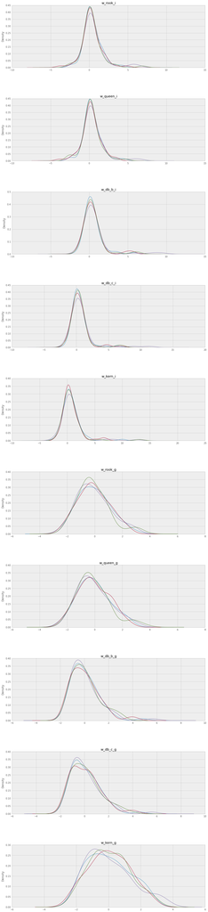

```python
plt.rcParams['figure.figsize']=15,70

#Set list of weight matrices
w_list=['w_rook_i','w_queen_i','w_db_b_i','w_db_c_i','w_kern_i','w_rook_g','w_queen_g','w_db_b_g','w_db_c_g','w_kern_g']

#Create plotting figures
fig,axes=plt.subplots(10,1)

#For each weight matrix type..
for i in range(len(w_list)):
    #...and within each matrix type, for each 5-year interval
    for j in range(1987,2007,5):
        #...plot the kernel density of the values for Mpran's I (first five) and G* (second five)
        co_sp_dict['yr'+str(j)][w_list[i]].plot(kind='kde',ax=axes[i],title=w_list[i])
```

There are a few characteristics that stand out:

1. Variation is substantially higher in $G_i^*$, which indicates relative consistency in clustering activity, with larger variation in the magnitude of clustering values. This could mean simultaneous revenue capacity transitions occur in multiple counties within given neighborhoods.
2. Variation is generally more substantial in the higher values for both statistics. For Moran's $I_i$, this indicates varying intensity of spatial association amongst similar values. For $G_i^*$, this indicates low revenue capacity counties are more tightly coupled than high revenue capacity counties.
3. Central tendency generally leans right of zero for $I_i$, while leaning left of zero for $G_i^*$. This suggests a tendency towards the existence of spatial clustering, but this clustering occurs more often among low revenue capacity jurisdictions.

## Estimating the Impact of Tax and Expenditure Limitations on Fiscal Clustering

Having established that clustering occurs within a given year and the clustering dynamic changes over time, it remains to be seen whether or not TELs have a significant role to play in determining the extent of clustering activity. The impact of TELs will be estimated in four ways.

- **Ordinary Least Squares** - OLS will serve as a non-spatial pooled estimate

$y=X\beta+\epsilon$

- **Spatial Error Model** - The error term in this model seeks to mitigate spatial dependency across counties

$y=X\beta+\epsilon$ and

$\epsilon=\gamma W \epsilon + u$

becomes $y=\gamma Wy + X\beta-\gamma WX\beta + \epsilon$

- **Spatial Lag Model** - This model explicitly incorporates the weighted average of neighborhood values

$y = \rho Wy + X\beta + \epsilon$

becomes $y=(I - \rho W)^{-1} X\beta + (I - \rho W)^{-1} \epsilon$

In the first model, the dependent variable ($y$) will be the clustering values generated above in the first run and the second run will utilize per capita revenue (the main fiscal convergence measure). In the last two models, $y$ represent revenue capacity. The focus on per capita revenue facilitates estimation of the impact of the neighborhood directly, as opposed to the stringency of the TEL.

- **Fixed Effect Spatial Lag Model** - This model both incorporates the weighted average of neighborhood values and the value of the observation in the preceding time period

$y=\lambda (I_T \otimes W_N)y + (\iota_T \otimes I_N)\mu + X\beta + \epsilon$

The independent variables ($X$) are as follows:

- **TEL Stringency** - The policy variable of interest
- **Relative County Per Capita Output** - Provides a sense of placement in the statewide distribution of economic capacity without being associated with Gross State Product
- **Gross State Product** - Provides information about the business cycle

#### Preparation of Data for Estimation Routines

The data must be arranged in a consolidated set before estimation.

```python
#Create container for year-specific dataframes
co_sp_list=[]

#For each year-specific dataframe in the dictionary...
for key in co_sp_dict.keys():
    #...deposit the dataframe into the container
    co_sp_list.append(co_sp_dict[key])

#Contantenate dataframes vertically
co_sp=pd.concat(co_sp_list)
co_sp
```

[output not shown]

Now, the relative per capita output must be calculated. The basis for this calculation is the total annual payroll by county, provided via the [SIC](http://www.census.gov/epcd/www/sic.html) and [NAICS](http://www.census.gov/eos/www/naics/index.html) series generated by the Census Bureau. This data has already been cleaned in the Notebook title CBP_summary.

```python
##Generate merge key for co_sp
#Grab county specific portion of GEOID
co_sp['fipsc']=co_sp['GEOID'].apply(lambda x: x[2:])
#Convert to integer
co_sp['fipscty']=co_sp['fipsc'].astype(int)
```

```python
#Read in data
c=pd.read_csv('cbp1986_2011_CO.csv')

#Subset to total annual payroll (as opposed to industry-specific) and to relevant time range
cbp=c[(c['s_n07']==0) & (c['year'].isin(range(1987,2010)))]

#Restrict columns to data and merge keys
cbp_sub=cbp.reindex(columns=['year','fipscty','ap'])

#Merge data
co_sp_cbp=pd.merge(co_sp,cbp_sub,how='left',left_on=['AUDIT_YEAR','fipscty'],right_on=['year','fipscty'])

#Generate payroll per capita
co_sp_cbp['pcap']=(co_sp_cbp['ap']/co_sp_cbp['CTY_POP'])*1000

#Generate year-specific means
ap_co=co_sp_cbp[['AUDIT_YEAR','pcap']].groupby('AUDIT_YEAR').mean()

#Merge with parent set
co_sp_cbp=pd.merge(co_sp_cbp,ap_co.reset_index(),on='AUDIT_YEAR',suffixes=('','_mean'))

#Create relative per capita annual payroll measure
co_sp_cbp['pcap_rel']=co_sp_cbp['pcap']/co_sp_cbp['pcap_mean']

co_sp_cbp[['AUDIT_YEAR','fipscty','pcap','pcap_mean','pcap_rel']].head()
```

|  | AUDIT_YEAR | fipscty | pcap | pcap_mean | pcap_rel |
| --- | --- | --- | --- | --- | --- |
| 0 | 1992 | 53 | 3010.940919 | 5047.937064 | 0.596470 |
| 1 | 1992 | 29 | 2193.520102 | 5047.937064 | 0.434538 |
| 2 | 1992 | 47 | 14646.895273 | 5047.937064 | 2.901561 |
| 3 | 1992 | 23 | 837.981824 | 5047.937064 | 0.166005 |
| 4 | 1992 | 57 | 4099.476440 | 5047.937064 | 0.812109 |

```python
#Read in data
gsp=pd.read_csv('co_gsp.csv')

#Merge with parent dataframe
co_sp_cbp=pd.merge(co_sp_cbp,gsp,how='left',on='AUDIT_YEAR')
co_sp_cbp[['AUDIT_YEAR','fipscty','pcap','pcap_mean','pcap_rel','gsp']].head()
```

|  | AUDIT_YEAR | fipscty | pcap | pcap_mean | pcap_rel | gsp |
| --- | --- | --- | --- | --- | --- | --- |
| 0 | 1992 | 53 | 3010.940919 | 5047.937064 | 0.596470 | 97058 |
| 1 | 1992 | 29 | 2193.520102 | 5047.937064 | 0.434538 | 97058 |
| 2 | 1992 | 47 | 14646.895273 | 5047.937064 | 2.901561 | 97058 |
| 3 | 1992 | 23 | 837.981824 | 5047.937064 | 0.166005 | 97058 |
| 4 | 1992 | 57 | 4099.476440 | 5047.937064 | 0.812109 | 97058 |

#### Ordinary Least Squares

The first model to be run ignores spatial association and the panel structure of the data. It is meant to serve purely as a baseline to better understand the impact of incorporating these features into the estimation process.

A few items of note regarding modeling with [PySAL](http://pythonhosted.org/PySAL/index.html):

- The dependent variable, $y$, must be structured as an $n \times 1$ numpy array
- The regressor matrix, $X$, must be structured as a $n \times j$ numpy array, where $j$ is the number of independent variables
- As a consequence of working with numpy arrays, labeling information must be explicitly entered as parameters to the model

In keeping with the above practice, all weight matrices will be tested.

```python
def ols_by_w(w):
    """This function is utility to facilitate looping through all weighting schemes.
    Note: data are subset to provide only non-null values in relative annual payroll per capita.
    The collection of annual payroll data in one county did not begin until 2002."""
    #Set dependent variable
    y=co_sp_cbp[w][co_sp_cbp['pcap_rel'].notnull()].values

    #Adhere to the structure constraints imposed by PySAL
    y.shape=(len(co_sp_cbp[w][co_sp_cbp['pcap_rel'].notnull()]),1)

    #Create container for regressors
    X=[]

    #Add regressors to container in turn
    X.append(co_sp_cbp['intensity'][co_sp_cbp['pcap_rel'].notnull()].values)
    X.append(co_sp_cbp['pcap_rel'][co_sp_cbp['pcap_rel'].notnull()].values)
    X.append(co_sp_cbp['gsp'][co_sp_cbp['pcap_rel'].notnull()].values)

    #Convert from j x n to n x j (again to adhere to PySAL structure constraints
    X=np.array(X).T

    #Run model
    ols=pysal.spreg.ols.OLS(y,X,name_y=w,name_x=['TEL_intensity','pc_payroll','gsp'],name_ds='co_spatial_fiscal')
    return ols
print '***TEST RUN - Dependent = Local Morans I with Kernel Neighborhood Definition***\n'
print ols_by_w('w_kern_i').summary
```

```
***TEST RUN - Dependent = Local Morans I with Kernel Neighborhood Definition***

REGRESSION
----------
SUMMARY OF OUTPUT: ORDINARY LEAST SQUARES
-----------------------------------------
Data set            :co_spatial_fiscal
Dependent Variable  :    w_kern_i               Number of Observations:        1457
Mean dependent var  :      0.7452               Number of Variables   :           4
S.D. dependent var  :      1.7441               Degrees of Freedom    :        1453

R-squared           :    0.008178
Adjusted R-squared  :      0.0061
Sum squared residual:    4392.813               F-statistic           :      3.9938
Sigma-square        :       3.023               Prob(F-statistic)     :    0.007605
S.E. of regression  :       1.739               Log likelihood        :   -2871.359
Sigma-square ML     :       3.015               Akaike info criterion :    5750.718
S.E of regression ML:      1.7364               Schwarz criterion     :    5771.855

------------------------------------------------------------------------------------
            Variable     Coefficient       Std.Error     t-Statistic     Probability
------------------------------------------------------------------------------------
            CONSTANT       0.8880705       0.1868406       4.7530909       0.0000022
       TEL_intensity       0.0344098       0.0671672       0.5123005       0.6085186
                 gsp      -0.0000002       0.0000009      -0.2771145       0.7817316
          pc_payroll      -0.1953614       0.0565230      -3.4563180       0.0005634
------------------------------------------------------------------------------------

REGRESSION DIAGNOSTICS
MULTICOLLINEARITY CONDITION NUMBER         9.794822

TEST ON NORMALITY OF ERRORS
TEST                             DF        VALUE           PROB
Jarque-Bera                       2    14130.069654        0.0000000

DIAGNOSTICS FOR HETEROSKEDASTICITY
RANDOM COEFFICIENTS
TEST                             DF        VALUE           PROB
Breusch-Pagan test                3       68.466615        0.0000000
Koenker-Bassett test              3        8.632518        0.0345976

SPECIFICATION ROBUST TEST
TEST                             DF        VALUE           PROB
White                             9       22.087431        0.0086060
================================ END OF REPORT =====================================
```

The diagnostics indicate non-normality and heteroskedasticity, as would be expected where both spatial and temporal dependency are factors. Nevertheless, it is interesting to note that higher output per capita is associated with lower spatial clustering for the kernel weighting scheme.

```python
from pyGDsandbox.dataIO import multi_model_tab

#Create container for ols models
ols_list=[]

#For each weight matrix variable...
for w in w_list:
    #...run a model with the matrix variable as the dependent, and deposit in container
    ols_list.append(ols_by_w(w))

#Examine results
multi_model_tab(ols_list, model_names=w_list)
```

|  | 1-w_rook_i betas | 1-w_rook_i p | 2-w_queen_i betas | 2-w_queen_i p | 3-w_db_b_i betas | 3-w_db_b_i p | 4-w_db_c_i betas | 4-w_db_c_i p | 5-w_kern_i betas | 5-w_kern_i p | 6-w_rook_g betas | 6-w_rook_g p | 7-w_queen_g betas | 7-w_queen_g p | 8-w_db_b_g betas | 8-w_db_b_g p | 9-w_db_c_g betas | 9-w_db_c_g p | 10-w_kern_g betas | 10-w_kern_g p |
| --- | --- | --- | --- | --- | --- | --- | --- | --- | --- | --- | --- | --- | --- | --- | --- | --- | --- | --- | --- | --- |
| CONSTANT | 0.783 | *** | 0.6563 | *** | 0.6156 | *** | 0.682 | *** | 0.8881 | *** | 0.4132 | *** | 0.3441 | *** | 0.1341 |  | 0.1719 |  | 0.5241 | *** |
| TEL_intensity | 0.0158 |  | 0.0659 |  | 0.0525 |  | 0.0656 |  | 0.0344 |  | -0.1653 | *** | -0.1518 | *** | -0.1192 | *** | -0.1177 | ** | -0.2663 | *** |
| gsp | -0 |  | -0 |  | -0 |  | -0 |  | -0 |  | 0.0 |  | 0.0 |  | 0.0 |  | 0.0 |  | 0.0 | ** |
| pc_payroll | -0.414 | *** | -0.4093 | *** | -0.2092 | *** | -0.2499 | *** | -0.1954 | *** | -0.0805 | ** | -0.0639 | * | 0.1417 | *** | 0.1319 | *** | 0.0286 |  |
| N | 1457 |  | 1457 |  | 1457 |  | 1457 |  | 1457 |  | 1457 |  | 1457 |  | 1457 |  | 1457 |  | 1457 |  |
| R^2 | 0.0731 |  | 0.0764 |  | 0.0153 |  | 0.0186 |  | 0.0082 |  | 0.0163 |  | 0.0122 |  | 0.0118 |  | 0.0097 |  | 0.0195 |  |

It is interesting to note that while TEL intensity had no clear impact on the Moran's $I_i$ measures, the magnitude of the impact was consistently larger and significant to 95% confidence. Again, however, this model is intended to only serve as as a baseline. Furthermore, no model explained more than 7.6% of the variation.

One can also estimate the impacts on per capita revenue to facilitate comparison with models that use this indicator as the dependent. The function created above effectively took the dependent variable as the input parameter, so it can be used again for this purpose.

```python
print ols_by_w('pcrev').summary
```

```
REGRESSION
----------
SUMMARY OF OUTPUT: ORDINARY LEAST SQUARES
-----------------------------------------
Data set            :co_spatial_fiscal
Dependent Variable  :       pcrev               Number of Observations:        1457
Mean dependent var  :   1406.9450               Number of Variables   :           4
S.D. dependent var  :    832.4153               Degrees of Freedom    :        1453

R-squared           :    0.055589
Adjusted R-squared  :      0.0536
Sum squared residual:952801613.896               F-statistic           :     28.5084
Sigma-square        :  655747.842               Prob(F-statistic)     :   6.535e-18
S.E. of regression  :     809.783               Log likelihood        :  -11822.578
Sigma-square ML     :  653947.573               Akaike info criterion :   23653.157
S.E of regression ML:    808.6702               Schwarz criterion     :   23674.293

------------------------------------------------------------------------------------
            Variable     Coefficient       Std.Error     t-Statistic     Probability
------------------------------------------------------------------------------------
            CONSTANT    1349.1642646      87.0164147      15.5047099       0.0000000
       TEL_intensity    -203.4223015      31.2814604      -6.5029669       0.0000000
                 gsp       0.0028110       0.0004151       6.7716306       0.0000000
          pc_payroll     154.2864407      26.3241846       5.8610150       0.0000000
------------------------------------------------------------------------------------

REGRESSION DIAGNOSTICS
MULTICOLLINEARITY CONDITION NUMBER         9.794822

TEST ON NORMALITY OF ERRORS
TEST                             DF        VALUE           PROB
Jarque-Bera                       2      941.718103        0.0000000

DIAGNOSTICS FOR HETEROSKEDASTICITY
RANDOM COEFFICIENTS
TEST                             DF        VALUE           PROB
Breusch-Pagan test                3       32.198163        0.0000005
Koenker-Bassett test              3       14.010314        0.0028911

SPECIFICATION ROBUST TEST
TEST                             DF        VALUE           PROB
White                             9       49.669763        0.0000001
================================ END OF REPORT =====================================
```

The assumptions of normality and homoskedasticity are again violated, as expected. It is, however, interesting to note that TEL intensity is a more prevalent force in this model, and generally associated with a drop in revenue per capita. This clearly accords with intuition.

#### Spatial Error Model

The use of a Spatial Error Model (SEM) is employed here as an attempt to incorporate some of the dependency structure that has plagued the above OLS models. In particular, the model integrates the weight matrix into the error term. In this way, the model seeks to remove the dependency complication, but not actally explain its impact. The latter is the goal of the Spatial Lag Model. SEM is "a special case of a regression with a non-spherical error term, in which the off-diagonal elements of the covariance matrix express the structure of spatial dependence." (Rey & Anselin ) While OLS estimation of coefficients remains unbiased, efficiency is diminished and estimates of standard errors are biased.

From a practical standpoint, SEM is implemented via the two-stage least squares method developed by Kelejian and Prucha (1998). Estimation of the model cannot be done in a pooled fashion because the weight matrix applies to a given set of geography, with each member of that set holding a single record. Consequently, the analysis must be run for each year in the dataset.

A further complication arises due to the missing data in Broomfield County alluded to above. Missing data exists until 2001. Thus, if we restrict the dataset to only non-null values, those first 15 years carry only 63 geographic observations. The weight matrices, on the other hand, were constructed on the entire set of 64. Recall the structure of the model:

$y=\gamma Wy + X\beta-\gamma WX\beta + \epsilon$

In this model, $y$ is $n \times 1$ and $X$ is $n \times j$ where $j$ is the number of regressors. If $W$ is $(n+1) \times (n+1)$, the model cannot be estimated due to the matrix dimensionality mismatch preventing the calculation of the product. To mitigate this issue, the chosen strategy is to leverage the fact that the model seeks to estimate the average effect by inserting the year-specific mean. In this way, we seek to reduce the impact of these observations by allowing them only to affect the observation count. Since **pcap_rel** was calculated to be the ratio of the measured value to the year-specific mean of **pcap**, the mean is simply 1.

```python
#Create a copy
co_sp_cbp['pcap_rel2']=co_sp_cbp['pcap_rel'].fillna(1)
print co_sp_cbp[['AUDIT_YEAR','pcap_rel','pcap_rel2','FNAME']][co_sp_cbp['FNAME']=='Broomfield']
```

```
      AUDIT_YEAR  pcap_rel  pcap_rel2       FNAME
62          1992       NaN   1.000000  Broomfield
126         1993       NaN   1.000000  Broomfield
190         1990       NaN   1.000000  Broomfield
254         1991       NaN   1.000000  Broomfield
318         1996       NaN   1.000000  Broomfield
382         1997       NaN   1.000000  Broomfield
446         1987       NaN   1.000000  Broomfield
510         1995       NaN   1.000000  Broomfield
574         1989       NaN   1.000000  Broomfield
638         1988       NaN   1.000000  Broomfield
702         1998       NaN   1.000000  Broomfield
766         1999       NaN   1.000000  Broomfield
830         2005  3.469752   3.469752  Broomfield
894         2004  3.542023   3.542023  Broomfield
958         2007  3.068335   3.068335  Broomfield
1022        2006  3.338228   3.338228  Broomfield
1086        2001       NaN   1.000000  Broomfield
1150        2000       NaN   1.000000  Broomfield
1214        2003  3.504911   3.504911  Broomfield
1278        2002  4.003979   4.003979  Broomfield
1342        2009  3.041202   3.041202  Broomfield
1406        2008  2.977776   2.977776  Broomfield
1470        1994       NaN   1.000000  Broomfield
```

It should be noted that restricting the analysis to annual cross-sections has the effect of removing all variation in the gross state product. Consequently, this regressor must be removed from the specification.

```python
def sem_by_w_yr(ydep,w,yr):
    """This function is utility to facilitate looping through all years and weighting schemes.
    Note: data are subset to provide only non-null values in relative annual payroll per capita.
    The collection of annual payroll data in one county did not begin until 2002."""
    #Set dependent variable
    y=co_sp_cbp[ydep][co_sp_cbp['AUDIT_YEAR']==yr].values

    #Adhere to the structure constraints imposed by PySAL
    y.shape=(len(co_sp_cbp[ydep][co_sp_cbp['AUDIT_YEAR']==yr]),1)

    #Create container for regressors
    X=[]

    #Add regressors to container in turn
    X.append(co_sp_cbp['intensity'][co_sp_cbp['AUDIT_YEAR']==yr].values)
    X.append(co_sp_cbp['pcap_rel2'][co_sp_cbp['AUDIT_YEAR']==yr].values)

    #Convert from j x n to n x j (again to adhere to PySAL structure constraints
    X=np.array(X).T

    #Row standardize weight matrix
    w.transform='r'

    #Run model
    sem=pysal.spreg.error_sp.GM_Error(y,X,w=w,name_y=ydep,name_x=['TEL_intensity','pc_payroll'],name_ds='co_spatial_fiscal')
    return sem
print sem_by_w_yr('pcrev',w_rook,1993).summary
```

```
REGRESSION
----------
SUMMARY OF OUTPUT: SPATIALLY WEIGHTED LEAST SQUARES
---------------------------------------------------
Data set            :co_spatial_fiscal
Weights matrix      :     unknown
Dependent Variable  :       pcrev               Number of Observations:          64
Mean dependent var  :   1349.2703               Number of Variables   :           3
S.D. dependent var  :    883.0170               Degrees of Freedom    :          61

Pseudo R-squared    :    0.036119

------------------------------------------------------------------------------------
            Variable     Coefficient       Std.Error     z-Statistic     Probability
------------------------------------------------------------------------------------
            CONSTANT    -253.2341230    1711.5309892      -0.1479577       0.8823762
       TEL_intensity     453.5207429     569.3542838       0.7965528       0.4257108
          pc_payroll     290.2482528     150.6171664       1.9270596       0.0539722
              lambda       0.5139982
------------------------------------------------------------------------------------
================================ END OF REPORT =====================================
```

```python
#Create list of weight matrices
wm_list=[w_rook,w_queen,w_db_b,w_db_c,w_kern]

#Create container for SEMs
sem_list=[]

#For each weight matrix...
for w in wm_list:
    #...and each year within each weight matrix...
    for yr in range(1993,2010):
        #...do your best to run the SEM (subject to structural constraints on the weight matrix) and throw it in a list.
        try:
            sem_list.append(sem_by_w_yr('pcrev',w,yr))
        #If it doesn't work out, let me know where the problem occurred.
        except:
            print 'THERE WAS A PROBLEM WITH THE',w,'MATRIX IN',yr
```

```
THERE WAS A PROBLEM WITH THE <pysal.weights.Distance.Kernel object at 0x44332d0> MATRIX IN 1993
THERE WAS A PROBLEM WITH THE <pysal.weights.Distance.Kernel object at 0x44332d0> MATRIX IN 1994
THERE WAS A PROBLEM WITH THE <pysal.weights.Distance.Kernel object at 0x44332d0> MATRIX IN 1995
THERE WAS A PROBLEM WITH THE <pysal.weights.Distance.Kernel object at 0x44332d0> MATRIX IN 1996
THERE WAS A PROBLEM WITH THE <pysal.weights.Distance.Kernel object at 0x44332d0> MATRIX IN 1997
THERE WAS A PROBLEM WITH THE <pysal.weights.Distance.Kernel object at 0x44332d0> MATRIX IN 1998
THERE WAS A PROBLEM WITH THE <pysal.weights.Distance.Kernel object at 0x44332d0> MATRIX IN 1999
THERE WAS A PROBLEM WITH THE <pysal.weights.Distance.Kernel object at 0x44332d0> MATRIX IN 2000
THERE WAS A PROBLEM WITH THE <pysal.weights.Distance.Kernel object at 0x44332d0> MATRIX IN 2001
THERE WAS A PROBLEM WITH THE <pysal.weights.Distance.Kernel object at 0x44332d0> MATRIX IN 2002
THERE WAS A PROBLEM WITH THE <pysal.weights.Distance.Kernel object at 0x44332d0> MATRIX IN 2003
THERE WAS A PROBLEM WITH THE <pysal.weights.Distance.Kernel object at 0x44332d0> MATRIX IN 2004
THERE WAS A PROBLEM WITH THE <pysal.weights.Distance.Kernel object at 0x44332d0> MATRIX IN 2005
THERE WAS A PROBLEM WITH THE <pysal.weights.Distance.Kernel object at 0x44332d0> MATRIX IN 2006
THERE WAS A PROBLEM WITH THE <pysal.weights.Distance.Kernel object at 0x44332d0> MATRIX IN 2007
THERE WAS A PROBLEM WITH THE <pysal.weights.Distance.Kernel object at 0x44332d0> MATRIX IN 2008
THERE WAS A PROBLEM WITH THE <pysal.weights.Distance.Kernel object at 0x44332d0> MATRIX IN 2009
```

It appears that the kernel matrix carries non-zero elements on the diagonal. This seems unusual and may result in submission of an [issue](https://github.com/pysal/pysal/issues) at a later date. In the meantime, visual display of each parameter estimate over time would be informative of an evolving dynamic.

```python
print sem_by_w_yr('pcrev',w_rook,1993).summary
```

```
REGRESSION
----------
SUMMARY OF OUTPUT: SPATIALLY WEIGHTED LEAST SQUARES
---------------------------------------------------
Data set            :co_spatial_fiscal
Weights matrix      :     unknown
Dependent Variable  :       pcrev               Number of Observations:          64
Mean dependent var  :   1349.2703               Number of Variables   :           3
S.D. dependent var  :    883.0170               Degrees of Freedom    :          61

Pseudo R-squared    :    0.036119

------------------------------------------------------------------------------------
            Variable     Coefficient       Std.Error     z-Statistic     Probability
------------------------------------------------------------------------------------
            CONSTANT    -253.2341230    1711.5309892      -0.1479577       0.8823762
       TEL_intensity     453.5207429     569.3542838       0.7965528       0.4257108
          pc_payroll     290.2482528     150.6171664       1.9270596       0.0539722
              lambda       0.5139982
------------------------------------------------------------------------------------
================================ END OF REPORT =====================================
```

```python
#Create containers for parameter values
int_list=[]
TEL_list=[]
pay_list=[]
lambda_list=[]
TEL_p_list=[]
pay_p_list=[]

#For each SEM...
for sem in sem_list:
    #...grab the parameter estimates and throw them in lists
    int_list.append(sem.betas.T[0][0])
    TEL_list.append(sem.betas.T[0][1])
    pay_list.append(sem.betas.T[0][2])
    lambda_list.append(sem.betas.T[0][3])
    TEL_p_list.append(sem.z_stat[1][1])
    pay_p_list.append(sem.z_stat[2][1])

#Build index columns
yr_list=range(1993,2010)*4
wlab_list=['w_rook']*17+['w_queen']*17+['w_db_b']*17+['w_db_c']*17

#Build a dataframe from the captured data
sem_yr=DataFrame({'intercept':int_list,
                'TEL_intensity':TEL_list,
                'pc_payroll':pay_list,
                'lambda':lambda_list,
                'TEL_p':TEL_p_list,
                'pcpay_p':pay_p_list,
                'year':yr_list,
                'w_matrix':wlab_list})

sem_yr.head(20)
```

|  | TEL_intensity | TEL_p | intercept | lambda | pc_payroll | pcpay_p | w_matrix | year |
| --- | --- | --- | --- | --- | --- | --- | --- | --- |
| 0 | 453.520743 | 0.425711 | -253.234123 | 0.513998 | 290.248253 | 0.053972 | w_rook | 1993 |
| 1 | 333.706397 | 0.232609 | 148.931816 | 0.612896 | 242.363555 | 0.044552 | w_rook | 1994 |
| 2 | -116.087689 | 0.534492 | 1435.129132 | 0.438004 | 206.147968 | 0.070143 | w_rook | 1995 |
| 3 | -235.136723 | 0.073582 | 1682.167837 | 0.395582 | 247.489063 | 0.033754 | w_rook | 1996 |
| 4 | -253.239624 | 0.020451 | 1685.803427 | 0.519252 | 225.513228 | 0.041442 | w_rook | 1997 |
| 5 | -255.227245 | 0.029266 | 1745.542621 | 0.553264 | 220.560324 | 0.058138 | w_rook | 1998 |
| 6 | -262.766924 | 0.026657 | 1707.245973 | 0.557982 | 257.981875 | 0.028354 | w_rook | 1999 |
| 7 | -279.778266 | 0.023646 | 2170.442390 | 0.502815 | 166.316663 | 0.179078 | w_rook | 2000 |
| 8 | -260.378611 | 0.036936 | 2097.042381 | 0.489063 | 163.803547 | 0.185287 | w_rook | 2001 |
| 9 | -181.544526 | 0.179881 | 1718.420463 | 0.391934 | 299.565708 | 0.032332 | w_rook | 2002 |
| 10 | -124.238013 | 0.289067 | 1487.232881 | 0.503619 | 332.657123 | 0.006955 | w_rook | 2003 |
| 11 | -135.462827 | 0.256029 | 1512.735442 | 0.430970 | 341.259313 | 0.008138 | w_rook | 2004 |
| 12 | -124.823716 | 0.333938 | 1564.406542 | 0.538396 | 327.752909 | 0.013634 | w_rook | 2005 |
| 13 | -278.450366 | 0.049971 | 2059.486393 | 0.390516 | 367.314933 | 0.008716 | w_rook | 2006 |
| 14 | -333.912573 | 0.035727 | 2242.330493 | 0.424444 | 387.871599 | 0.019903 | w_rook | 2007 |
| 15 | -370.802028 | 0.021272 | 2461.177836 | 0.383952 | 298.717129 | 0.078106 | w_rook | 2008 |
| 16 | -370.807847 | 0.027959 | 2641.287750 | 0.557287 | 219.973785 | 0.251227 | w_rook | 2009 |
| 17 | 454.702385 | 0.433838 | -240.549221 | 0.442664 | 268.558226 | 0.073928 | w_queen | 1993 |
| 18 | 287.960187 | 0.316366 | 292.524541 | 0.519614 | 221.043662 | 0.070539 | w_queen | 1994 |
| 19 | -166.489028 | 0.375551 | 1582.676391 | 0.383432 | 195.335357 | 0.086504 | w_queen | 1995 |

Varying color by continuous value is more easily achieved in [ggplot2](http://ggplot2.org/) (R) than [matplotlib](http://matplotlib.org/) (Python). For this reason, capturing p_values is facilitate by pushing the dataframe into the R namespace.

```python
%load_ext rmagic
```

```
The rmagic extension is already loaded. To reload it, use:
  %reload_ext rmagic
```

```python
import pandas.rpy.common as com

#Convert pandas DataFrame to R data.frame
sem_yr_r=com.convert_to_r_dataframe(sem_yr)

#Push new data.frame into the R namespace
%Rpush sem_yr_r
```

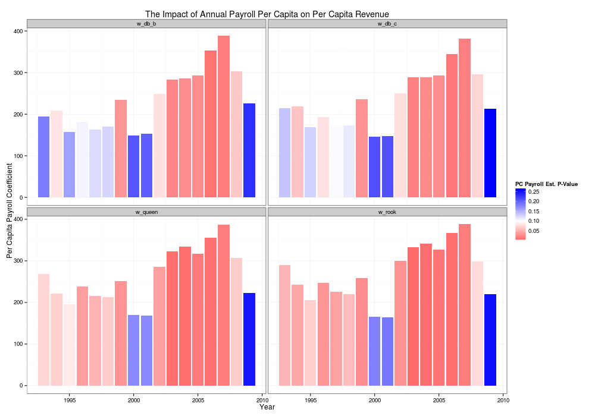

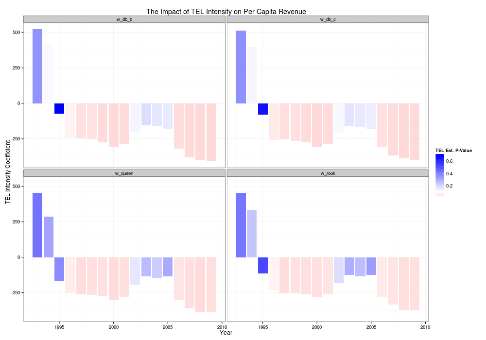

```python
%%R -w 1000 -h 700

library(ggplot2)

tel_plot<-ggplot(sem_yr_r,aes(x=as.numeric(year),y=as.numeric(TEL_intensity),fill=as.numeric(TEL_p)))+
        geom_bar(stat='identity')+
        scale_fill_gradient2(low='red',high='blue',midpoint=.1)+
        labs(x='Year',y='TEL Intensity Coefficient',fill='TEL Est. P-Value')+
        ggtitle('The Impact of TEL Intensity on Per Capita Revenue')+
        theme_bw()+
        facet_wrap(~ w_matrix)
print(tel_plot)

pay_plot<-ggplot(sem_yr_r,aes(x=as.numeric(year),y=as.numeric(pc_payroll),fill=as.numeric(pcpay_p)))+
        geom_bar(stat='identity')+
        scale_fill_gradient2(low='red',high='blue',midpoint=.1)+
        labs(x='Year',y='Per Capita Payroll Coefficient',fill='PC Payroll Est. P-Value')+
        ggtitle('The Impact of Annual Payroll Per Capita on Per Capita Revenue')+
        theme_bw()+
        facet_wrap(~ w_matrix)
print(pay_plot)
```

In the plots above, the magnitude of the coefficient for a given year-specific SEM is provided by the height of the bar. The color is set by the $p$-value. Red signifies lower values, so deeper reds indicate clearer statistical signals. Blue, as may be expected, operates in opposite fashion. The midpoint for color divergence is set at $p$=0.1. Thus, anything on the red side of white can be said to be a measure of greater than 90% confidence (and vice versa).

Across all four matrices, a fairly consistent narrative arises. The impact of payroll on per capita trends more positively over time, while the impact of TEL stringency trends more negatively. While these models explain a limited amount of the variation in TEL stringency, these data do seem to indicate TELs become more restrictive over time. This accords with intuition, as the combined effect of the TEL policies in Colorado applies asymmetric pressure to revenue capacity. The baseline for allowable revenue in the following year is far more easily lowered than raised.

#### Spatial Lag Model

To reiterate, while Spatial Error Models (SEMs) seek to diminish the impacts of a "nuisance" spatial dependency structure, Spatial Lag Models (SLMs) seek to model the neighborhood impacts directly. The time series equivalent of this task would be an autoregressive specification seeking to model the impact of preceding observations $y_{t-1},y_{t-2},...,y_{t-n}$ on the current observation $y_t$.

$Y_t=\alpha + \sum_{i=1}^p \rho_i Y_{t-i} + X\beta + \epsilon_t$

In the spatial context, this "autoregressive" impact captures the weighted average of the values for all neighboring geographies, $y_j \forall j \neq i$, in the neighborhood (defined by $W$) of geography unit $y_i$.

$y =\alpha + \rho Wy + X\beta + \epsilon$

Much like the SEM, the SLM is a cross-sectional model that must be run for each year.

```python
import pysal.spreg.diagnostics as D

def slm_by_w_yr(ydep,lag,w,yr):
    """This function is utility to facilitate looping through all years and weighting schemes.
    Note: data are subset to provide only non-null values in relative annual payroll per capita.
    The collection of annual payroll data in one county did not begin until 2002."""
    #Set dependent variable
    y=co_sp_cbp[ydep][co_sp_cbp['AUDIT_YEAR']==yr].values

    #Adhere to the structure constraints imposed by PySAL
    y.shape=(len(co_sp_cbp[ydep][co_sp_cbp['AUDIT_YEAR']==yr]),1)

    #Create container for regressors
    X=[]

    #Add regressors to container in turn
    X.append(co_sp_cbp['intensity'][co_sp_cbp['AUDIT_YEAR']==yr].values)
    X.append(co_sp_cbp['pcap_rel2'][co_sp_cbp['AUDIT_YEAR']==yr].values)

    #Convert from j x n to n x j (again to adhere to PySAL structure constraints
    X=np.array(X).T

    #Row standardize weight matrix
    w.transform='r'

    #Run model
    slm=pysal.spreg.twosls_sp.GM_Lag(y,X,w=w,w_lags=lag,name_y=ydep,name_x=['TEL_intensity','pc_payroll'],name_ds='co_spatial_fiscal')
    return slm
print slm_by_w_yr('pcrev',2,w_rook,1993).summary
```

```
REGRESSION
----------
SUMMARY OF OUTPUT: SPATIAL TWO STAGE LEAST SQUARES
--------------------------------------------------
Data set            :co_spatial_fiscal
Weights matrix      :     unknown
Dependent Variable  :       pcrev               Number of Observations:          64
Mean dependent var  :   1349.2703               Number of Variables   :           4
S.D. dependent var  :    883.0170               Degrees of Freedom    :          60

Pseudo R-squared    :      0.0981
Spatial Pseudo R-squared:  0.0176

------------------------------------------------------------------------------------
            Variable     Coefficient       Std.Error     z-Statistic     Probability
------------------------------------------------------------------------------------
            CONSTANT    -1014.9926523    3216.2645632      -0.3155812       0.7523204
       TEL_intensity     460.8785835     599.3532605       0.7689598       0.4419172
             W_pcrev       0.5832155       1.8675579       0.3122878       0.7548218
          pc_payroll     226.2686368     182.2324398       1.2416485       0.2143663
------------------------------------------------------------------------------------
Instrumented: W_pcrev
Instruments: W2_TEL_intensity, W2_pc_payroll, W_TEL_intensity, W_pc_payroll
================================ END OF REPORT =====================================
```

While the SLM does appear to explain more of the variation relative to the SEM (and OLS estimation), it is clear the current specification has limited explanatory power. Nevertheless, observing the impact of TEL intensity over time can yet again yield some insight.

```python
#Create container for SLMs
slm_list=[]

#Create containers for year and weight matrix labels
yr_list=[]
wlab_list=[]
lag_list=[]

#For each weight matrix...
for w in wm_list:
    #...and each year within each weight matrix...
    for yr in range(1993,2010):
        #...and each of four lags within each year, within each weight matrix...
        for lag in range(1,5):
            #...do your best to run the SLM (subject to structural constraints on the weight matrix) and throw it in a list.
            try:
                slm_list.append(slm_by_w_yr('pcrev',lag,w,yr))
                yr_list.append(yr)
                wlab_list.append(w)
                lag_list.append(lag)
            #If it doesn't work out, let me know where the problem occurred.
            except:
                print 'THERE WAS A PROBLEM WITH THE',w,'MATRIX IN',yr,'WITH LAG',lag
```

[output not shown]

```python
#Create containers for parameter values
int_list_yr=[]
TEL_list_yr=[]
pay_list_yr=[]
TEL_p_list_yr=[]
pay_p_list_yr=[]

#For each SEM...
for slm in slm_list:
    #...grab the parameter estimates and throw them in lists
    int_list_yr.append(slm.betas.T[0][0])
    TEL_list_yr.append(slm.betas.T[0][1])
    pay_list_yr.append(slm.betas.T[0][2])
    TEL_p_list_yr.append(slm.z_stat[1][1])
    pay_p_list_yr.append(slm.z_stat[2][1])

#Build a dataframe from the captured data
slm_yr=DataFrame({'intercept':int_list_yr,
                'TEL_intensity':TEL_list_yr,
                'pc_payroll':pay_list_yr,
                'TEL_p':TEL_p_list_yr,
                'pcpay_p':pay_p_list_yr,
                'year':yr_list,
                'w_matrix_temp':wlab_list,
                'lag':lag_list})

#Create weight matrix labeling dict
w_dict={w_rook:'w_rook',
        w_queen:'w_queen',
        w_db_b:'w_db_b',
        w_db_c:'w_db_c',
        w_kern:'w_kern'}

#Insert text labels for w_matrix and drop object reference
slm_yr['w_matrix']=slm_yr['w_matrix_temp'].map(w_dict)
slm_yr.pop('w_matrix_temp')

slm_yr.head(20)
```

|  | TEL_intensity | TEL_p | intercept | lag | pc_payroll | pcpay_p | year | w_matrix |
| --- | --- | --- | --- | --- | --- | --- | --- | --- |
| 0 | 466.066353 | 0.447167 | -1465.622994 | 1 | 246.952630 | 0.432673 | 1993 | w_rook |
| 1 | 460.878583 | 0.441917 | -1014.992652 | 2 | 226.268637 | 0.214366 | 1993 | w_rook |
| 2 | 461.585688 | 0.441599 | -1076.414563 | 3 | 229.087911 | 0.201867 | 1993 | w_rook |
| 3 | 453.789217 | 0.455932 | -399.181985 | 4 | 198.002845 | 0.224282 | 1993 | w_rook |
| 4 | -47.354696 | 0.841861 | -21.469893 | 1 | 202.954876 | 0.073332 | 1995 | w_rook |
| 5 | -91.542829 | 0.673758 | 381.547714 | 2 | 192.303069 | 0.078217 | 1995 | w_rook |
| 6 | -78.010200 | 0.713901 | 258.123452 | 3 | 195.565188 | 0.073072 | 1995 | w_rook |
| 7 | -71.006166 | 0.738184 | 194.243204 | 4 | 197.253551 | 0.071221 | 1995 | w_rook |
| 8 | -205.688116 | 0.165562 | 333.549211 | 1 | 230.899764 | 0.043371 | 1996 | w_rook |
| 9 | -208.951905 | 0.153644 | 396.509606 | 2 | 229.278246 | 0.043019 | 1996 | w_rook |
| 10 | -206.500924 | 0.185998 | 2114.017643 | 1 | 159.418567 | 0.273251 | 1997 | w_rook |
| 11 | -238.751665 | 0.044941 | 1347.548613 | 2 | 191.090232 | 0.078120 | 1997 | w_rook |
| 12 | -266.550968 | 0.021964 | 686.872176 | 3 | 218.390387 | 0.038593 | 1997 | w_rook |
| 13 | -229.300088 | 0.144693 | 1858.067765 | 1 | 184.946838 | 0.166232 | 1998 | w_rook |
| 14 | -257.503264 | 0.040771 | 1099.158409 | 2 | 206.594378 | 0.061221 | 1998 | w_rook |
| 15 | -276.442764 | 0.026312 | 589.522075 | 3 | 221.131519 | 0.044057 | 1998 | w_rook |
| 16 | -221.906619 | 0.087189 | 1977.571557 | 1 | 208.569657 | 0.081287 | 1999 | w_rook |
| 17 | -227.955985 | 0.060119 | 1577.975051 | 2 | 214.655741 | 0.054395 | 1999 | w_rook |
| 18 | -236.248971 | 0.042645 | 1030.174128 | 3 | 222.999063 | 0.037508 | 1999 | w_rook |
| 19 | -246.386799 | 0.039682 | 360.510448 | 4 | 233.198425 | 0.034228 | 1999 | w_rook |

```python
#Convert pandas DataFrame to R data.frame
slm_yr_r=com.convert_to_r_dataframe(slm_yr)

#Push new data.frame into the R namespace
%Rpush slm_yr_r
```

Note that, as a consequence of the lag parameter input, the set pushed into the R namespace this time carries an extra dimension. To provide a similar view to that which was generated for the SEM, the data will be subset to second order lags.

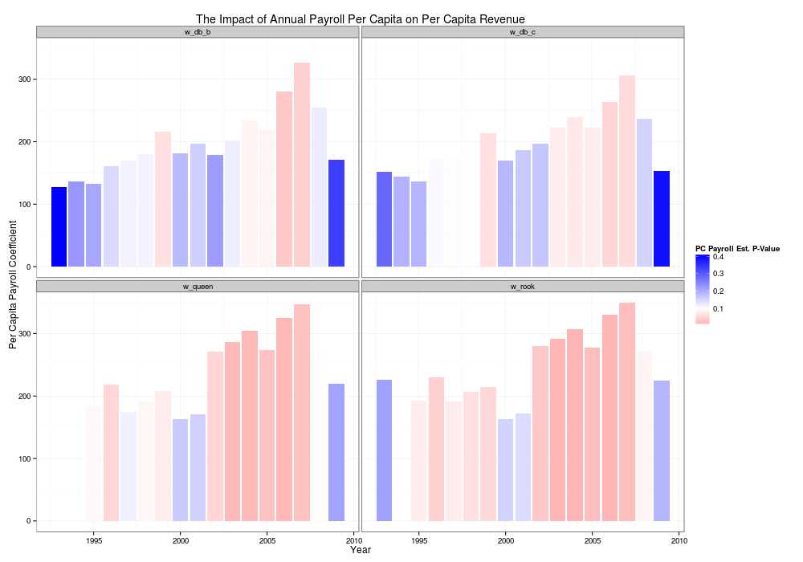

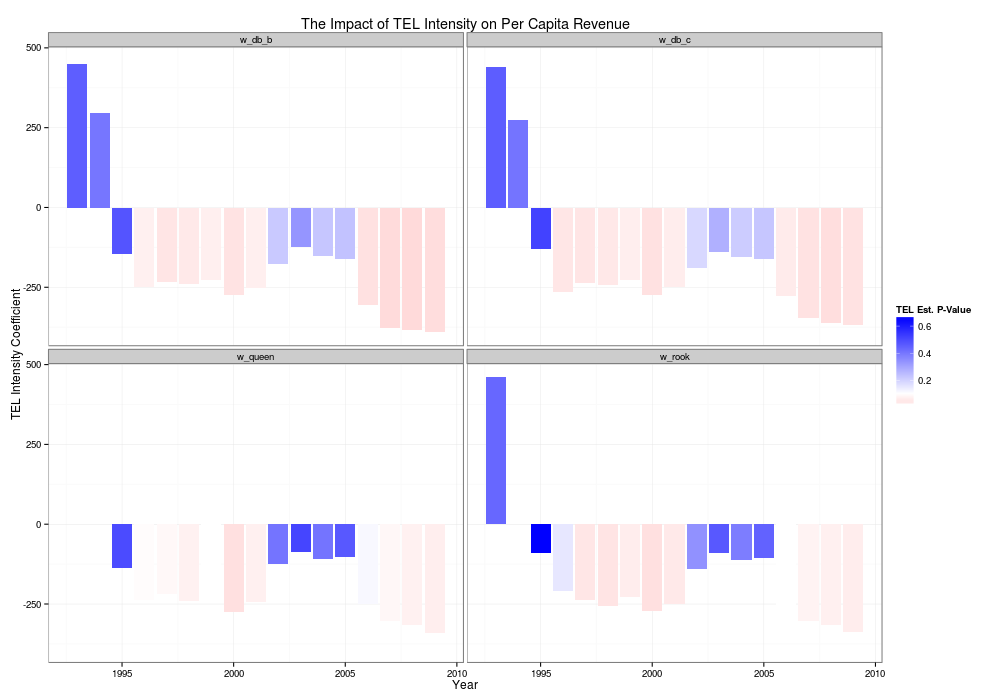

```python
%%R -w 1000 -h 700

library(ggplot2)

slm2<-slm_yr_r[slm_yr_r$lag==2,]

tel_plot_slm2<-ggplot(slm2,aes(x=as.numeric(year),y=as.numeric(TEL_intensity),fill=as.numeric(TEL_p)))+
        geom_bar(stat='identity')+
        scale_fill_gradient2(low='red',high='blue',midpoint=.1)+
        labs(x='Year',y='TEL Intensity Coefficient',fill='TEL Est. P-Value')+
        ggtitle('The Impact of TEL Intensity on Per Capita Revenue')+
        theme_bw()+
        facet_wrap(~ w_matrix)
print(tel_plot_slm2)

pay_plot_slm2<-ggplot(slm2,aes(x=as.numeric(year),y=as.numeric(pc_payroll),fill=as.numeric(pcpay_p)))+
        geom_bar(stat='identity')+
        scale_fill_gradient2(low='red',high='blue',midpoint=.1)+
        labs(x='Year',y='Per Capita Payroll Coefficient',fill='PC Payroll Est. P-Value')+
        ggtitle('The Impact of Annual Payroll Per Capita on Per Capita Revenue')+
        theme_bw()+
        facet_wrap(~ w_matrix)
print(pay_plot_slm2)
```

In truth, the action is very similar to that uncovered by the SEM routines. The same increasingly positive impact of payroll occurs, as does the same increasingly negative impact of TEL intensity. The same strange sign reversal in the impact of TEL intensity occurs in the third year. It is conceivable that this impact is driven by Colorado's biennial assessment schedule, insofar as adjusting to the new post-TABOR regime was a lumpy affair.

In the interests of understanding the impact of specification, it is useful to determine variation over time using different lags. In the following plots, the weight matrix dimension is held constant. The chosen weight matrix is w_rook (rook contiguity).

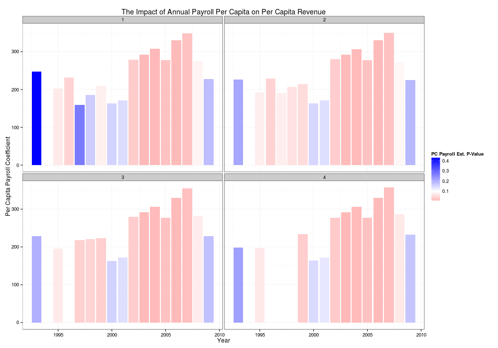

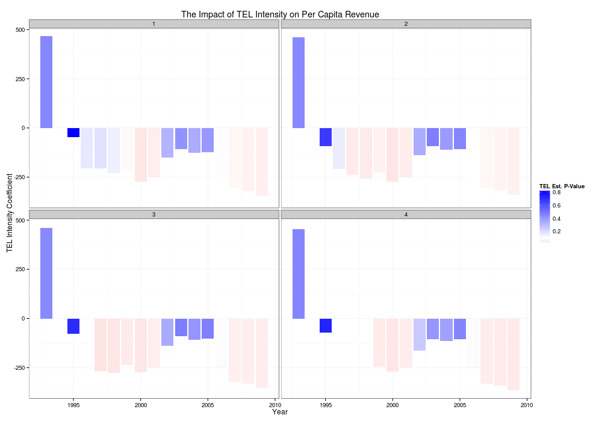

```python
%%R -w 1000 -h 700

slm3<-slm_yr_r[slm_yr_r$w_matrix=='w_rook',]

tel_plot_slm3<-ggplot(slm3,aes(x=as.numeric(year),y=as.numeric(TEL_intensity),fill=as.numeric(TEL_p)))+
        geom_bar(stat='identity')+
        scale_fill_gradient2(low='red',high='blue',midpoint=.1)+
        labs(x='Year',y='TEL Intensity Coefficient',fill='TEL Est. P-Value')+
        ggtitle('The Impact of TEL Intensity on Per Capita Revenue')+
        theme_bw()+
        facet_wrap(~ lag)
print(tel_plot_slm3)

pay_plot_slm3<-ggplot(slm3,aes(x=as.numeric(year),y=as.numeric(pc_payroll),fill=as.numeric(pcpay_p)))+
        geom_bar(stat='identity')+
        scale_fill_gradient2(low='red',high='blue',midpoint=.1)+
        labs(x='Year',y='Per Capita Payroll Coefficient',fill='PC Payroll Est. P-Value')+
        ggtitle('The Impact of Annual Payroll Per Capita on Per Capita Revenue')+
        theme_bw()+
        facet_wrap(~ lag)
print(pay_plot_slm3)
```

#### Fixed Effects Spatial Lag Model

Much like the Spatial Lag Model (SLM) above, the Fixed Effects Spatial Lag Model (FESLM) captures the neighborhood impact explicitly in the model specification. The difference is in the ability to also capture the value from the previous time period. Recall the stacked form of the model (Millo & Piras 2012).

$y=\lambda (I_T \otimes W_N)y + (\iota_T \otimes I_N)\mu + X\beta + \epsilon$

Unpacking this model illuminates how it extends the earlier SLM.

- $\lambda$ = spatial autoregressive coefficient
- $I_T$ = $T \times T$ identity matrix
- $W_N$ = spatial weights matrix
- $\iota_T$ = vector of ones of dimension $T$
- $I_N$ = $N \times N$ identity matrix
- $\mu$ = individual-specific effect
- $\epsilon_i$ = spherical errors

The first term, $\lambda (I_T \otimes W_N)y$, captures both the temporal ($\lambda I_T y$) and spatial ($\lambda W_N y$) autocorrelation factors. The fixed effects $\mu$ are distributed across time and space by $(\iota_T \otimes I_N)$. As a reminder, the [Kronecker product](http://en.wikipedia.org/wiki/Kronecker_product) ($\otimes$) generates a block matrix in which every element of one matrix is multiplied with every element of a second matrix. In practice, this model drops the individual-specific effect $\mu$ (a.k.a. eliminating the time invariant effects), by subtracting the average for each cross-section over time (much like the operation calculating relative per capita revenue above). This removes the intercept and fixed effect component all together, resulting in the following form:

$y^*=\lambda(I_T \otimes W_N)y^* + X*\beta + \epsilon^*$

```python
print co_sp_cbp[co_sp_cbp['ap'].notnull()]
#Convert pandas DataFrame to R data.frame
co_sp_r=com.convert_to_r_dataframe(co_sp_cbp)

#Push new data.frame into the R namespace
%Rpush co_sp_r
```

[output not shown]

[output not shown]

```python
%%R
library(sp)
library(maptools)
library(spdep)
library(plm)
library(splm)

#Read in CO shapefile
c<-readShapeSpatial('/home/choct155/Google Drive/Dissertation/Data/spatial/US/co_county.shp')

#Convert to nb object
c_nb<-poly2nb(c)

#Convert to listw object
c_lw<-nb2listw(c_nb)

#Convert to pdata.frame
pdata.frame(co_sp_cbp,'FNAME','AUDIT_YEAR')

print(summary(co_sp_cbp))
print(traceback())
```

[output not shown]

```python
co_sp_cbp
```

[output not shown]